# Risk Factor Analysis

## Outcome Variable

**Outcome Variable:** s03rec24

## Predictor Variables

**Intervention Variable:** birthlen

**Adjustment Set:**

unadjusted

## Stratifying Variables

The analysis was stratified on these variable(s):

- studyid
- country

## Data Summary

| studyid | country | A | n | nA | nAY0 | nAY1 |
| --- | --- | --- | --- | --- | --- | --- |
| ki0047075b-MAL-ED | BANGLADESH | >=0 | 233 | 39 | 39 | 0 |
| ki0047075b-MAL-ED | BANGLADESH | <-3 | 233 | 6 | 5 | 1 |
| ki0047075b-MAL-ED | BANGLADESH | [-3–2) | 233 | 26 | 20 | 6 |
| ki0047075b-MAL-ED | BANGLADESH | [-2–1) | 233 | 74 | 70 | 4 |
| ki0047075b-MAL-ED | BANGLADESH | [-1-0) | 233 | 88 | 88 | 0 |
| ki0047075b-MAL-ED | BRAZIL | >=0 | 179 | 44 | 44 | 0 |
| ki0047075b-MAL-ED | BRAZIL | <-3 | 179 | 5 | 0 | 5 |
| ki0047075b-MAL-ED | BRAZIL | [-3–2) | 179 | 8 | 1 | 7 |
| ki0047075b-MAL-ED | BRAZIL | [-2–1) | 179 | 45 | 37 | 8 |
| ki0047075b-MAL-ED | BRAZIL | [-1-0) | 179 | 77 | 77 | 0 |
| ki0047075b-MAL-ED | INDIA | >=0 | 199 | 34 | 34 | 0 |
| ki0047075b-MAL-ED | INDIA | <-3 | 199 | 6 | 6 | 0 |
| ki0047075b-MAL-ED | INDIA | [-3–2) | 199 | 22 | 13 | 9 |
| ki0047075b-MAL-ED | INDIA | [-2–1) | 199 | 65 | 60 | 5 |
| ki0047075b-MAL-ED | INDIA | [-1-0) | 199 | 72 | 70 | 2 |
| ki0047075b-MAL-ED | NEPAL | >=0 | 171 | 45 | 45 | 0 |
| ki0047075b-MAL-ED | NEPAL | <-3 | 171 | 5 | 5 | 0 |
| ki0047075b-MAL-ED | NEPAL | [-3–2) | 171 | 12 | 6 | 6 |
| ki0047075b-MAL-ED | NEPAL | [-2–1) | 171 | 45 | 42 | 3 |
| ki0047075b-MAL-ED | NEPAL | [-1-0) | 171 | 64 | 64 | 0 |
| ki0047075b-MAL-ED | PERU | >=0 | 261 | 42 | 42 | 0 |
| ki0047075b-MAL-ED | PERU | <-3 | 261 | 4 | 4 | 0 |
| ki0047075b-MAL-ED | PERU | [-3–2) | 261 | 21 | 15 | 6 |
| ki0047075b-MAL-ED | PERU | [-2–1) | 261 | 86 | 72 | 14 |
| ki0047075b-MAL-ED | PERU | [-1-0) | 261 | 108 | 102 | 6 |
| ki0047075b-MAL-ED | SOUTH AFRICA | >=0 | 249 | 59 | 58 | 1 |
| ki0047075b-MAL-ED | SOUTH AFRICA | <-3 | 249 | 1 | 1 | 0 |
| ki0047075b-MAL-ED | SOUTH AFRICA | [-3–2) | 249 | 19 | 9 | 10 |
| ki0047075b-MAL-ED | SOUTH AFRICA | [-2–1) | 249 | 70 | 57 | 13 |
| ki0047075b-MAL-ED | SOUTH AFRICA | [-1-0) | 249 | 100 | 97 | 3 |
| ki0047075b-MAL-ED | TANZANIA, UNITED REPUBLIC OF | >=0 | 119 | 24 | 24 | 0 |
| ki0047075b-MAL-ED | TANZANIA, UNITED REPUBLIC OF | <-3 | 119 | 5 | 5 | 0 |
| ki0047075b-MAL-ED | TANZANIA, UNITED REPUBLIC OF | [-3–2) | 119 | 10 | 10 | 0 |
| ki0047075b-MAL-ED | TANZANIA, UNITED REPUBLIC OF | [-2–1) | 119 | 32 | 32 | 0 |
| ki0047075b-MAL-ED | TANZANIA, UNITED REPUBLIC OF | [-1-0) | 119 | 48 | 48 | 0 |
| ki1000108-CMC-V-BCS-2002 | INDIA | >=0 | 92 | 14 | 13 | 1 |
| ki1000108-CMC-V-BCS-2002 | INDIA | <-3 | 92 | 3 | 2 | 1 |
| ki1000108-CMC-V-BCS-2002 | INDIA | [-3–2) | 92 | 13 | 11 | 2 |
| ki1000108-CMC-V-BCS-2002 | INDIA | [-2–1) | 92 | 22 | 21 | 1 |
| ki1000108-CMC-V-BCS-2002 | INDIA | [-1-0) | 92 | 40 | 38 | 2 |
| ki1000108-IRC | INDIA | >=0 | 388 | 143 | 137 | 6 |
| ki1000108-IRC | INDIA | <-3 | 388 | 16 | 10 | 6 |
| ki1000108-IRC | INDIA | [-3–2) | 388 | 27 | 18 | 9 |
| ki1000108-IRC | INDIA | [-2–1) | 388 | 65 | 57 | 8 |
| ki1000108-IRC | INDIA | [-1-0) | 388 | 137 | 123 | 14 |
| ki1000109-EE | PAKISTAN | >=0 | 1 | 1 | 1 | 0 |
| ki1000109-EE | PAKISTAN | <-3 | 1 | 0 | 0 | 0 |
| ki1000109-EE | PAKISTAN | [-3–2) | 1 | 0 | 0 | 0 |
| ki1000109-EE | PAKISTAN | [-2–1) | 1 | 0 | 0 | 0 |
| ki1000109-EE | PAKISTAN | [-1-0) | 1 | 0 | 0 | 0 |
| ki1000109-ResPak | PAKISTAN | >=0 | 3 | 1 | 1 | 0 |
| ki1000109-ResPak | PAKISTAN | <-3 | 3 | 0 | 0 | 0 |
| ki1000109-ResPak | PAKISTAN | [-3–2) | 3 | 0 | 0 | 0 |
| ki1000109-ResPak | PAKISTAN | [-2–1) | 3 | 0 | 0 | 0 |
| ki1000109-ResPak | PAKISTAN | [-1-0) | 3 | 2 | 2 | 0 |
| ki1017093b-PROVIDE | BANGLADESH | >=0 | 686 | 219 | 218 | 1 |
| ki1017093b-PROVIDE | BANGLADESH | <-3 | 686 | 1 | 1 | 0 |
| ki1017093b-PROVIDE | BANGLADESH | [-3–2) | 686 | 21 | 15 | 6 |
| ki1017093b-PROVIDE | BANGLADESH | [-2–1) | 686 | 168 | 152 | 16 |
| ki1017093b-PROVIDE | BANGLADESH | [-1-0) | 686 | 277 | 271 | 6 |
| ki1101329-Keneba | GAMBIA | >=0 | 1479 | 815 | 777 | 38 |
| ki1101329-Keneba | GAMBIA | <-3 | 1479 | 25 | 14 | 11 |
| ki1101329-Keneba | GAMBIA | [-3–2) | 1479 | 42 | 32 | 10 |
| ki1101329-Keneba | GAMBIA | [-2–1) | 1479 | 142 | 131 | 11 |
| ki1101329-Keneba | GAMBIA | [-1-0) | 1479 | 455 | 432 | 23 |
| ki1114097-CMIN | BANGLADESH | >=0 | 7 | 2 | 2 | 0 |
| ki1114097-CMIN | BANGLADESH | <-3 | 7 | 0 | 0 | 0 |
| ki1114097-CMIN | BANGLADESH | [-3–2) | 7 | 0 | 0 | 0 |
| ki1114097-CMIN | BANGLADESH | [-2–1) | 7 | 4 | 4 | 0 |
| ki1114097-CMIN | BANGLADESH | [-1-0) | 7 | 1 | 1 | 0 |
| ki1114097-CMIN | PERU | >=0 | 10 | 10 | 10 | 0 |
| ki1114097-CMIN | PERU | <-3 | 10 | 0 | 0 | 0 |
| ki1114097-CMIN | PERU | [-3–2) | 10 | 0 | 0 | 0 |
| ki1114097-CMIN | PERU | [-2–1) | 10 | 0 | 0 | 0 |
| ki1114097-CMIN | PERU | [-1-0) | 10 | 0 | 0 | 0 |
| ki1114097-CONTENT | PERU | >=0 | 2 | 1 | 1 | 0 |
| ki1114097-CONTENT | PERU | <-3 | 2 | 0 | 0 | 0 |
| ki1114097-CONTENT | PERU | [-3–2) | 2 | 0 | 0 | 0 |
| ki1114097-CONTENT | PERU | [-2–1) | 2 | 1 | 1 | 0 |
| ki1114097-CONTENT | PERU | [-1-0) | 2 | 0 | 0 | 0 |

The following strata were considered:

- studyid: ki0047075b-MAL-ED, country: BANGLADESH
- studyid: ki0047075b-MAL-ED, country: BRAZIL
- studyid: ki0047075b-MAL-ED, country: INDIA
- studyid: ki0047075b-MAL-ED, country: NEPAL
- studyid: ki0047075b-MAL-ED, country: PERU
- studyid: ki0047075b-MAL-ED, country: SOUTH AFRICA
- studyid: ki0047075b-MAL-ED, country: TANZANIA, UNITED REPUBLIC OF
- studyid: ki1000108-CMC-V-BCS-2002, country: INDIA
- studyid: ki1000108-IRC, country: INDIA
- studyid: ki1000109-EE, country: PAKISTAN
- studyid: ki1000109-ResPak, country: PAKISTAN
- studyid: ki1017093b-PROVIDE, country: BANGLADESH
- studyid: ki1101329-Keneba, country: GAMBIA
- studyid: ki1114097-CMIN, country: BANGLADESH
- studyid: ki1114097-CMIN, country: PERU
- studyid: ki1114097-CONTENT, country: PERU

### Dropped Strata

Some strata were dropped due to rare outcomes:

- studyid: ki0047075b-MAL-ED, country: BANGLADESH
- studyid: ki0047075b-MAL-ED, country: BRAZIL
- studyid: ki0047075b-MAL-ED, country: INDIA
- studyid: ki0047075b-MAL-ED, country: NEPAL
- studyid: ki0047075b-MAL-ED, country: PERU
- studyid: ki0047075b-MAL-ED, country: SOUTH AFRICA
- studyid: ki0047075b-MAL-ED, country: TANZANIA, UNITED REPUBLIC OF
- studyid: ki1000108-CMC-V-BCS-2002, country: INDIA
- studyid: ki1000109-EE, country: PAKISTAN
- studyid: ki1000109-ResPak, country: PAKISTAN
- studyid: ki1017093b-PROVIDE, country: BANGLADESH
- studyid: ki1114097-CMIN, country: BANGLADESH
- studyid: ki1114097-CMIN, country: PERU
- studyid: ki1114097-CONTENT, country: PERU

## Methods Detail

We’re interested in the causal parameters $E[Y_a]$ for all values of $a \in \mathcal{A}$. These parameters represent the mean outcome if, possibly contrary to fact, we intervened to set all units to have $A=a$. Under the randomization and positivity assumptions, these are identified by the statistical parameters $\psi_a=E_W[E_{Y|A,W}(Y|A=a,W)]$. In addition, we’re interested in the mean of $Y$, $E[Y]$ under no intervention (the observed mean). We will estimate these parameters by using SuperLearner to fit the relevant likelihood factors – $E_{Y|A,W}(Y|A=a,W)$ and $p(A=a|W)$, and then updating our likelihood fit using a joint TMLE.

For unadjusted analyses ($W=\{\}$), initial likelihoods were estimated using Lrnr_glm to estimate the simple $E(Y|A)$ and Lrnr_mean to estimate $p(A)$. For adjusted analyses, a small library containing Lrnr_glmnet, Lrnr_xgboost, and Lrnr_mean was used.

Having estimated these parameters, we will then use the delta method to estimate relative risks and attributable risks relative to a prespecified baseline level of $A$.

# Results Detail

## Results Plots

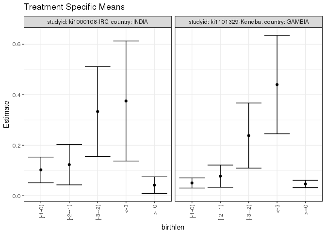

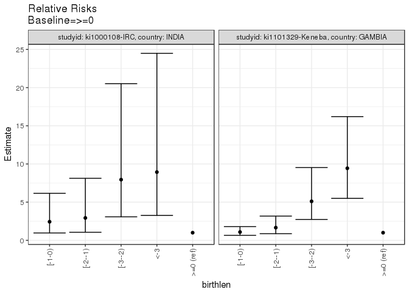

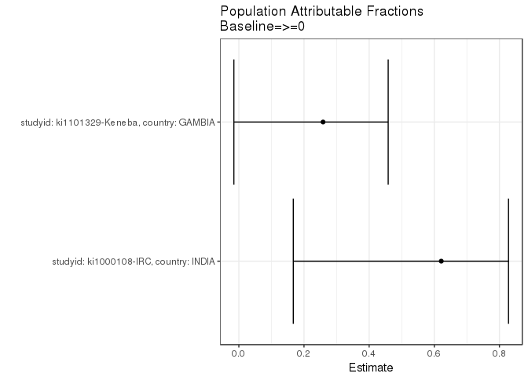

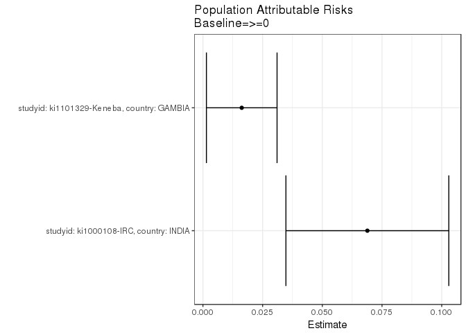

## Results Table

### Parameter: TSM

| studyid | country | intervention_level | baseline_level | estimate | ci_lower | ci_upper |
| --- | --- | --- | --- | --- | --- | --- |
| ki1000108-IRC | INDIA | >=0 | NA | 0.0419580 | 0.0090547 | 0.0748614 |
| ki1000108-IRC | INDIA | <-3 | NA | 0.3750000 | 0.1374778 | 0.6125222 |
| ki1000108-IRC | INDIA | [-3–2) | NA | 0.3333333 | 0.1552922 | 0.5113745 |
| ki1000108-IRC | INDIA | [-2–1) | NA | 0.1230769 | 0.0431081 | 0.2030458 |
| ki1000108-IRC | INDIA | [-1-0) | NA | 0.1021898 | 0.0514038 | 0.1529758 |
| ki1101329-Keneba | GAMBIA | >=0 | NA | 0.0466258 | 0.0321460 | 0.0611055 |
| ki1101329-Keneba | GAMBIA | <-3 | NA | 0.4400000 | 0.2453541 | 0.6346459 |
| ki1101329-Keneba | GAMBIA | [-3–2) | NA | 0.2380952 | 0.1092418 | 0.3669487 |
| ki1101329-Keneba | GAMBIA | [-2–1) | NA | 0.0774648 | 0.0334808 | 0.1214488 |
| ki1101329-Keneba | GAMBIA | [-1-0) | NA | 0.0505495 | 0.0304130 | 0.0706859 |

### Parameter: E(Y)

| studyid | country | intervention_level | baseline_level | estimate | ci_lower | ci_upper |
| --- | --- | --- | --- | --- | --- | --- |
| ki1000108-IRC | INDIA | NA | NA | 0.1108247 | 0.1018455 | 0.1198040 |
| ki1101329-Keneba | GAMBIA | NA | NA | 0.0628803 | 0.0598692 | 0.0658915 |

### Parameter: RR

| studyid | country | intervention_level | baseline_level | estimate | ci_lower | ci_upper |
| --- | --- | --- | --- | --- | --- | --- |
| ki1000108-IRC | INDIA | >=0 | >=0 | 1.000000 | 1.0000000 | 1.000000 |
| ki1000108-IRC | INDIA | <-3 | >=0 | 8.937499 | 3.2615837 | 24.490831 |
| ki1000108-IRC | INDIA | [-3–2) | >=0 | 7.944444 | 3.0760812 | 20.517725 |
| ki1000108-IRC | INDIA | [-2–1) | >=0 | 2.933333 | 1.0594403 | 8.121688 |
| ki1000108-IRC | INDIA | [-1-0) | >=0 | 2.435523 | 0.9624705 | 6.163069 |
| ki1101329-Keneba | GAMBIA | >=0 | >=0 | 1.000000 | 1.0000000 | 1.000000 |
| ki1101329-Keneba | GAMBIA | <-3 | >=0 | 9.436842 | 5.4965541 | 16.201785 |
| ki1101329-Keneba | GAMBIA | [-3–2) | >=0 | 5.106516 | 2.7361712 | 9.530291 |
| ki1101329-Keneba | GAMBIA | [-2–1) | >=0 | 1.661416 | 0.8697913 | 3.173523 |
| ki1101329-Keneba | GAMBIA | [-1-0) | >=0 | 1.084153 | 0.6542260 | 1.796607 |

### Parameter: PAR

| studyid | country | intervention_level | baseline_level | estimate | ci_lower | ci_upper |
| --- | --- | --- | --- | --- | --- | --- |
| ki1000108-IRC | INDIA | >=0 | NA | 0.0688667 | 0.0347601 | 0.1029733 |
| ki1101329-Keneba | GAMBIA | >=0 | NA | 0.0162546 | 0.0014650 | 0.0310441 |

### Parameter: PAF

| studyid | country | intervention_level | baseline_level | estimate | ci_lower | ci_upper |
| --- | --- | --- | --- | --- | --- | --- |
| ki1000108-IRC | INDIA | >=0 | NA | 0.6214018 | 0.1671558 | 0.8278951 |
| ki1101329-Keneba | GAMBIA | >=0 | NA | 0.2584999 | -0.0152581 | 0.4584407 |